# DNA Alignments Assignment

Jayde MacMillan  
20068250  
March 3, 2022

[Github repository](https://github.com/jaydealexandra/DNAAlignments.git)

## Setup

Loads the packages required.

```r
library(BiocManager)
library(Biostrings)
library(ggtree)
library(annotate)
library(muscle)
library(reshape2)
library(rentrez)
library(ape)
library(dplyr)
```

```r
library(ggplot2)
```

## Alignments

### Unknown Sequence

Saves the provided sequence as an object called ‘humanSeq’.

```r
humanSeq <- 'ATGTCTGATAATGGACCCCAAAATCAGCGAAATGCACCCCGCATTACGTTTGGTGGACCCTCAGATTCAA
CTGGCAGTAACCAGAATGGAGAACGCAGTGGGGCGCGATCAAAACAACGTCGGCCCCAAGGTTTACCCAA
TAATACTGCGTCTTGGTTCACCGCTCTCACTCAACATGGCAAGGAAGACCTTAAATTCCCTCGAGGACAA
GGCGTTCCAATTAACACCAATAGCAGTCCAGATGACCAAATTGGCTACTACCGAAGAGCTACCAGACGAA
TTCGTGGTGGTGACGGTAAAATGAAAGATCTCAGTCCAAGATGGTATTTCTACTACCTAGGAACTGGGCC
AGAAGCTGGACTTCCCTATGGTGCTAACAAAGACGGCATCATATGGGTTGCAACTGAGGGAGCCTTGAAT
ACACCAAAAGATCACATTGGCACCCGCAATCCTGCTAACAATGCTGCAATCGTGCTACAACTTCCTCAAG
GAACAACATTGCCAAAAGGCTTCTACGCAGAAGGGAGCAGAGGCGGCAGTCAAGCCTCTTCTCGTTCCTC
ATCACGTAGTCGCAACAGTTCAAGAAATTCAACTCCAGGCAGCAGTAGGGGAACTTCTCCTGCTAGAATG
GCTGGCAATGGCGGTGATGCTGCTCTTGCTTTGCTGCTGCTTGACAGATTGAACCAGCTTGAGAGCAAAA
TGTCTGGTAAAGGCCAACAACAACAAGGCCAAACTGTCACTAAGAAATCTGCTGCTGAGGCTTCTAAGAA
GCCTCGGCAAAAACGTACTGCCACTAAAGCATACAATGTAACACAAGCTTTCGGCAGACGTGGTCCAGAA
CAAACCCAAGGAAATTTTGGGGACCAGGAACTAATCAGACAAGGAACTGATTACAAACATTGGCCGCAAA
TTGCACAATTTGCCCCCAGCGCTTCAGCGTTCTTCGGAATGTCGCGCATTGGCATGGAAGTCACACCTTC
GGGAACGTGGTTGACCTACACAGGTGCCATCAAATTGGATGACAAAGATCCAAATTTCAAAGATCAAGTC
ATTTTGCTGAATAAGCATATTGACGCATACAAAACATTCCCACCAACAGAGCCTAAAAAGGACAAAAAGA
AGAAGGCTGATGAAACTCAAGCCTTACCGCAGAGACAGAAGAAACAGCAAACTGTGACTCTTCTTCCTGC
TGCAGATTTGGATGATTTCTCCAAACAATTGCAACAATCCATGAGCAGTGCTGACTCAACTCAGGCCTAA'
print(humanSeq)
```

```
## [1] "ATGTCTGATAATGGACCCCAAAATCAGCGAAATGCACCCCGCATTACGTTTGGTGGACCCTCAGATTCAA\nCTGGCAGTAACCAGAATGGAGAACGCAGTGGGGCGCGATCAAAACAACGTCGGCCCCAAGGTTTACCCAA\nTAATACTGCGTCTTGGTTCACCGCTCTCACTCAACATGGCAAGGAAGACCTTAAATTCCCTCGAGGACAA\nGGCGTTCCAATTAACACCAATAGCAGTCCAGATGACCAAATTGGCTACTACCGAAGAGCTACCAGACGAA\nTTCG…
```

### BLAST

Runs ‘humanSeq’ in BLAST to find similar sequences and turns the results into a data frame.

```r
humanSeqBLAST <- blastSequences(x= humanSeq, as = 'data.frame',   hitListSize = 30, timeout = 500)
```

```
## estimated response time 34 seconds
```

[output not shown]

[output not shown]

[output not shown]

[output not shown]

[output not shown]

[output not shown]

[output not shown]

[output not shown]

[output not shown]

[output not shown]

[output not shown]

[output not shown]

[output not shown]

[output not shown]

[output not shown]

[output not shown]

[output not shown]

[output not shown]

[output not shown]

[output not shown]

[output not shown]

[output not shown]

[output not shown]

Creates a vector of accession numbers from the BLAST results (humanSeqBLAST) and turns them into a data.frame object called ‘hsHitsDF’ with two columns (ID and Seq).

```r
hsHitsDF <- data.frame(ID=humanSeqBLAST$Hit_accession, Seq=humanSeqBLAST$Hsp_hseq, stringsAsFactors = FALSE)
```

Connects to the GenBank database and reads the nucleotide sequences using the accession numbers.

```r
humanHitSeqs <- read.GenBank(humanSeqBLAST$Hit_accession)
```

Displays the species.

```r
attr(humanHitSeqs, "species")
```

```
##  [1] "Severe_acute_respiratory_syndrome_coronavirus_2"
##  [2] "Severe_acute_respiratory_syndrome_coronavirus_2"
##  [3] "Severe_acute_respiratory_syndrome_coronavirus_2"
##  [4] "Severe_acute_respiratory_syndrome_coronavirus_2"
##  [5] "Severe_acute_respiratory_syndrome_coronavirus_2"
##  [6] "Severe_acute_respiratory_syndrome_coronavirus_2"
##  [7] "Severe_acute_respiratory_syndrome_coronavirus_2"
##  [8] "Severe_acute_respiratory_syndrome_coronavirus_2"
##  [9] "Severe_acute_respiratory_syndrome_coronavirus_2"
## [10] "Severe_acute_respiratory_syndrome_coronavirus_2"
## [11] "Severe_acute_respiratory_syndrome_coronavirus_2"
## [12] "Severe_acute_respiratory_syndrome_coronavirus_2"
## [13] "Severe_acute_respiratory_syndrome_coronavirus_2"
## [14] "Severe_acute_respiratory_syndrome_coronavirus_2"
## [15] "Severe_acute_respiratory_syndrome_coronavirus_2"
## [16] "Severe_acute_respiratory_syndrome_coronavirus_2"
## [17] "Severe_acute_respiratory_syndrome_coronavirus_2"
## [18] "Severe_acute_respiratory_syndrome_coronavirus_2"
## [19] "Severe_acute_respiratory_syndrome_coronavirus_2"
## [20] "Severe_acute_respiratory_syndrome_coronavirus_2"
## [21] "Severe_acute_respiratory_syndrome_coronavirus_2"
## [22] "Severe_acute_respiratory_syndrome_coronavirus_2"
## [23] "Severe_acute_respiratory_syndrome_coronavirus_2"
## [24] "Severe_acute_respiratory_syndrome_coronavirus_2"
## [25] "Severe_acute_respiratory_syndrome_coronavirus_2"
## [26] "Severe_acute_respiratory_syndrome_coronavirus_2"
## [27] "Severe_acute_respiratory_syndrome_coronavirus_2"
## [28] "Severe_acute_respiratory_syndrome_coronavirus_2"
## [29] "Severe_acute_respiratory_syndrome_coronavirus_2"
## [30] "Severe_acute_respiratory_syndrome_coronavirus_2"
```

As shown above, the sequences are from SARS-CoV-2. It is likely that the patient is suffering from this virus which is a cause for concern.

### MUSCLE Alignment

Using Multiple Sequence Comparison by Log-Expectation (MUSCLE), we can align multiple sequences of nucleotides with accuracy.

Pipes the data.frame ‘hsHitsDF’ to a DNAStringSet object called ‘humanHitsDNAstring’.

```r
humanHitsDNAstring <- hsHitsDF$Seq %>% # Start with the sequences
  as.character %>% # Converts to strings
  lapply(.,paste0,collapse="") %>% # Collapses to a single string
  unlist %>% # Flattens to a vector
  DNAStringSet # Converts to DNAStringSet object
```

Adds a name to each sequence.

```r
names(humanHitsDNAstring) <- paste(1:nrow(hsHitsDF), hsHitsDF$ID, sep="_")
```

Uses `muscle()` on ‘humanHitsDNAstring’ to align multiple sequences.

```r
hsAlign <- muscle::muscle(stringset=humanHitsDNAstring, quiet=T)
```

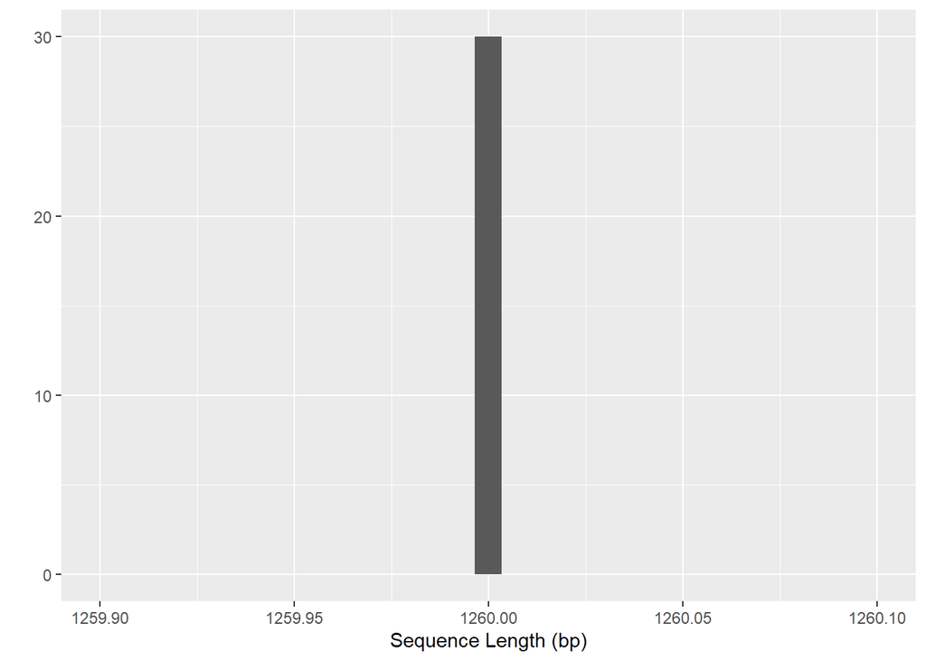

```r
hhSeqLen <- as.numeric(lapply(humanHitsDNAstring,length))
qplot(hhSeqLen, xlim= c(1259.9, 1260.1), ylim= c(0,30), xlab= "Sequence Length (bp)")
```

Figure 1. A plot showing the length of the sequences that match the original sequence. All of the matching sequences are 1260bp long.

### Distance Matrix

Converts the DNAMultipleAlignment object ‘hsAlign’ to a DNABin object called ‘hhAlignBin’ using the `as.DNAbin()` function.

```r
hhAlignBin <- as.DNAbin(hsAlign)
hhDM <- dist.dna(hhAlignBin, model="K80")
```

Rearrange from an n x n matrix to a ‘linear’ matrix using the `melt()` function.

```r
hhDMMat <- as.matrix(hhDM)
mhhDat <- melt(hhDMMat)
```

Creates a pairwise distance matrix of ‘mhhDat’.

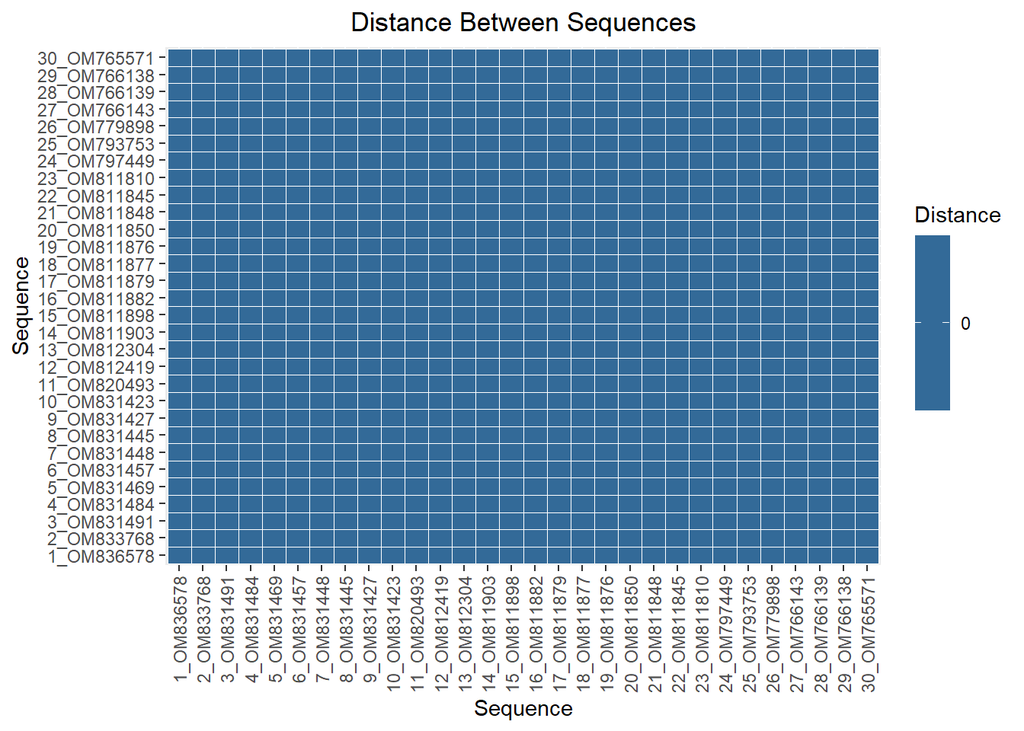

```r
ggplot(data=mhhDat, aes(x=Var1, y=Var2, fill=value))+
  geom_tile(color="white")+
  theme(axis.text.x = element_text(angle = 90, hjust = 1, vjust = 0.5), plot.title = element_text(hjust = 0.5))+
  labs(title= "Distance Between Sequences", x= "Sequence", y= "Sequence", fill= "Distance")
```

Figure 2. A pairwise distance matrix visualizing the distance between sequences.

## Phylogenetic Tree

Creates a neighbour-joining tree estimation using the `nj()` function.

```r
hhTree <- nj(hhDM)
```

Creates a plot of the phylogenetic tree using the `ggtree()` function.

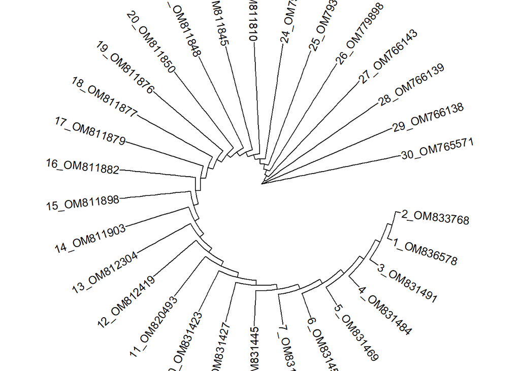

```r
ggtree(hhTree, branch.length = 'none', layout="fan") + geom_tiplab()
```

Figure 3. A phylogeny showing the evolutionary relationships between the sequences.

Saves the phylogenetic tree using the `write.tree()` function.

```r
write.tree(hhTree, "A6_MACMILLAN_JAYDE.tre")
```